# Verzani Problem Set

## Problem 11.2

Consider the data set `corn`. Twelve plots of land are divided into two and then one half of each is planted with a new corn seed, the other with the standard. Do a two-sample t-test on the data. Do the assumptions seems to be met. Comment why the matched sample test is more appropriate, and then perform the test. Did the two agree anyways?

```r
> head(corn)
  New Standard
1 110      102
2 103       86
3  95       88
4  94       75
5  87       89
6 119      102
```

First we need to check if the data is normally distributed.

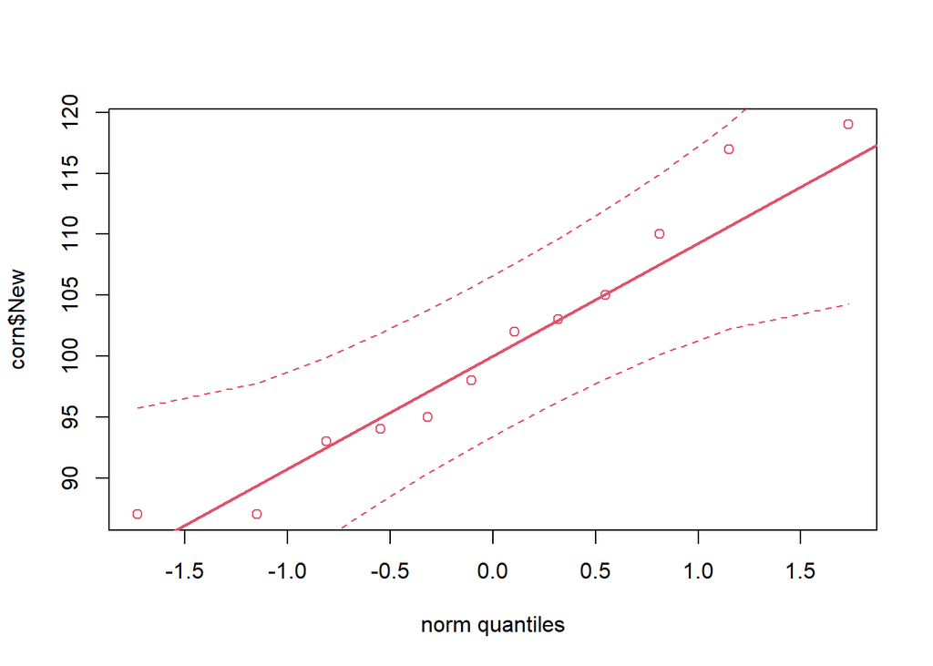

```r
> qqplot.das(corn$New)
```

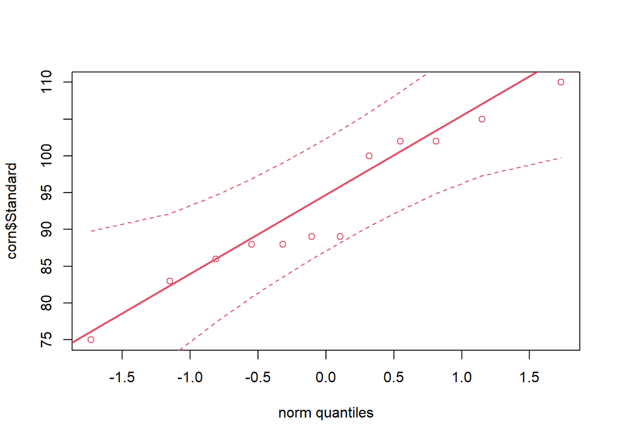

```r
> qqplot.das(corn$Standard)
```

Shapiro test for normality

```r
> shapiro.test(corn$New)

    Shapiro-Wilk normality test

data:  corn$New
W = 0.94358, p-value = 0.5457
```

The $p-value = 0.5457 > 0.05 = \alpha$, so we have no evidence to reject $H_0$. We can assume that the data is normally distributed.

```r
> shapiro.test(corn$Standard)

    Shapiro-Wilk normality test

data:  corn$Standard
W = 0.93955, p-value = 0.4923
```

The $p-value = 0.4923 > 0.05 = \alpha$, so we have no evidence to reject $H_0$. We can assume that the data is normally distributed.

Both have normal distributions, so we can use t-test
$$H_0: \mu_{new} = \mu_{standard}$$
$$H_A: \mu_{new} \neq \mu_{standard}$$
The data are paired as we divide the plots in two

```r
> t.test(corn$New, corn$Standard, paired = TRUE)

    Paired t-test

data:  corn$New and corn$Standard
t = 3.8308, df = 11, p-value = 0.00279
alternative hypothesis: true difference in means is not equal to 0
95 percent confidence interval:
  3.297258 12.202742
sample estimates:
mean of the differences
                   7.75
```

The $p-value = 0.00279 < 0.05 = \alpha$, so we reject $H_0$. The new and the standard seed doesn’t have the same mean.

## Problem 11.3

Consider the data set `blood`. Do a significance test for equivalent centers. Which one did you use and why? What was the p-value?

```r
> head(blood)
  Machine Expert
1      68     72
2      82     84
3      94     89
4     106    100
5      92     97
6      80     88
```

The data present the blood pressure of $15$ males taken by machine and expert, so we have paired samples.

We need to check if the data is normally distributed.

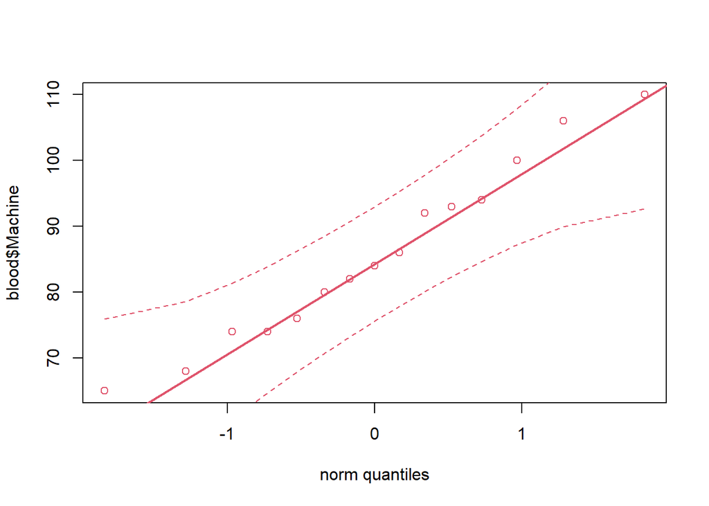

```r
> qqplot.das(blood$Machine)
```

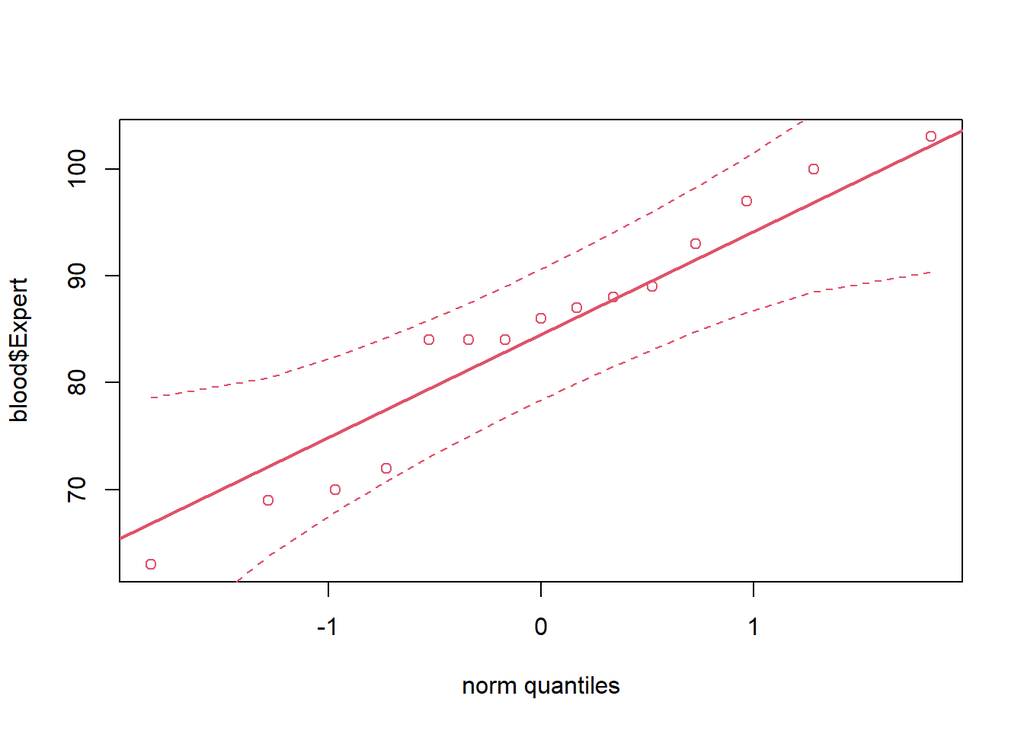

```r
> qqplot.das(blood$Expert)
```

Shapiro test for normality

```r
> shapiro.test(blood$Machine)

    Shapiro-Wilk normality test

data:  blood$Machine
W = 0.96996, p-value = 0.8575
```

The $p-value = 0.8575 > 0.05 = \alpha$, so we have no evidence to reject $H_0$. We can assume that the data is normally distributed.

```r
> shapiro.test(blood$Expert)

    Shapiro-Wilk normality test

data:  blood$Expert
W = 0.94816, p-value = 0.4959
```

The $p-value = 0.4959 > 0.05 = \alpha$, so we have no evidence to reject $H_0$. We can assume that the data is normally distributed.

Both have normal distributions, so we can use t-test
$$H_0: \mu_{machine} = \mu_{expert}$$
$$H_A: \mu_{machine} \neq \mu_{expert}$$

```r
> t.test(blood$Machine, blood$Expert, paired = TRUE)

    Paired t-test

data:  blood$Machine and blood$Expert
t = 0.68162, df = 14, p-value = 0.5066
alternative hypothesis: true difference in means is not equal to 0
95 percent confidence interval:
 -2.146615  4.146615
sample estimates:
mean of the differences
                      1
```

The $p-value = 0.5066 > 0.05 = \alpha$, so we have no evidence to reject $H_0$. The blood pressure taken by the machine and the expert has the same mean.

## Problem 11.4

Do a test of equality of medians on the `cabinets` data set. Why might this be more appropriate than a test for equality of the mean or is it?

```r
> head(cabinet)
             name          position est.dividend.cg est.tax.savings
1  George W. Bush         President           23947            5651
2     Dick Cheney    Vice President          493798          116002
3       John Snow  Sec. of Treasury         5500000          331594
4    Colin Powell     Sec. of State         1250000          109506
5 Donald Rumsfeld   Sec. of Defense         1300000           87327
6    Donald Evans  Sec. of Commerce          625448           68370
```

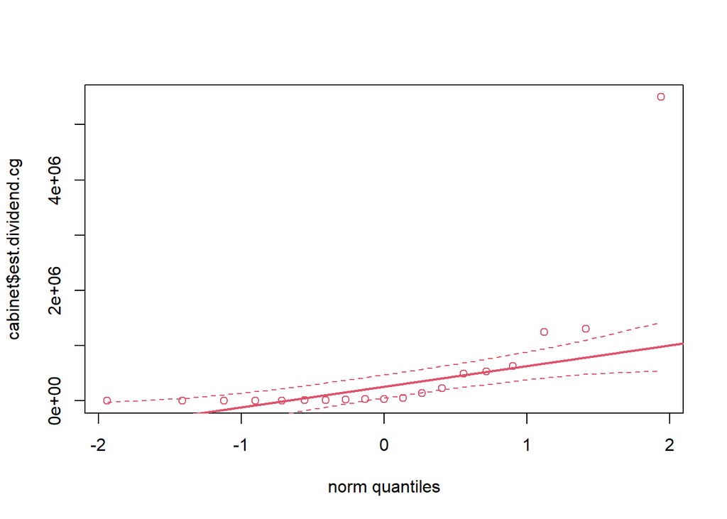

```r
> qqplot.das(cabinet$est.dividend.cg)
```

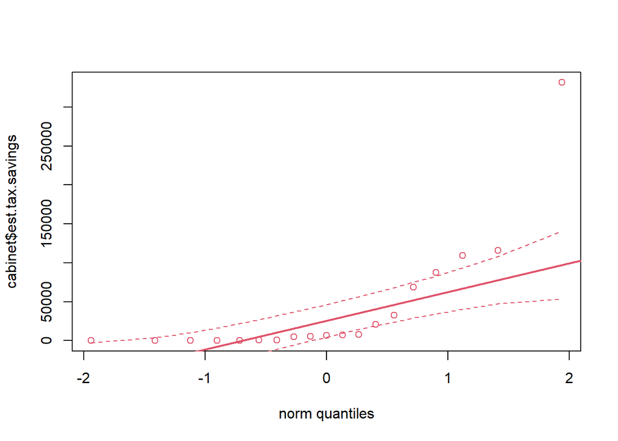

```r
> qqplot.das(cabinet$est.tax.savings)
```

Shapiro test for normality

```r
> shapiro.test(cabinet$est.dividend.cg)

    Shapiro-Wilk normality test

data:  cabinet$est.dividend.cg
W = 0.46916, p-value = 2.706e-07
```

```r
> shapiro.test(cabinet$est.tax.savings)

    Shapiro-Wilk normality test

data:  cabinet$est.tax.savings
W = 0.58517, p-value = 3.154e-06
```

Both are not normally distributed, so we can make test for equality of medians
$$H_0: Me_1 = Me_2$$
$$H_A: Me_1 \neq Me_2$$

```r
> wilcox.test(cabinet$est.dividend.cg, cabinet$est.tax.savings)

    Wilcoxon rank sum exact test

data:  cabinet$est.dividend.cg and cabinet$est.tax.savings
W = 258, p-value = 0.02333
alternative hypothesis: true location shift is not equal to 0
```

The $p-value = 0.02333 < 0.05 = \alpha$, so we reject $H_0$.